# Packet 3: Relationships among scales

Last updated 2018-04-05

This is an exploration of the relationships among scales included in Packet 3.

# Correlation matrix

First, let’s look at the overall correlationships among scores on the various scales included in Packet 3. (These are individual participant-level correlations):

```
Setting row names on a tibble is deprecated.
```

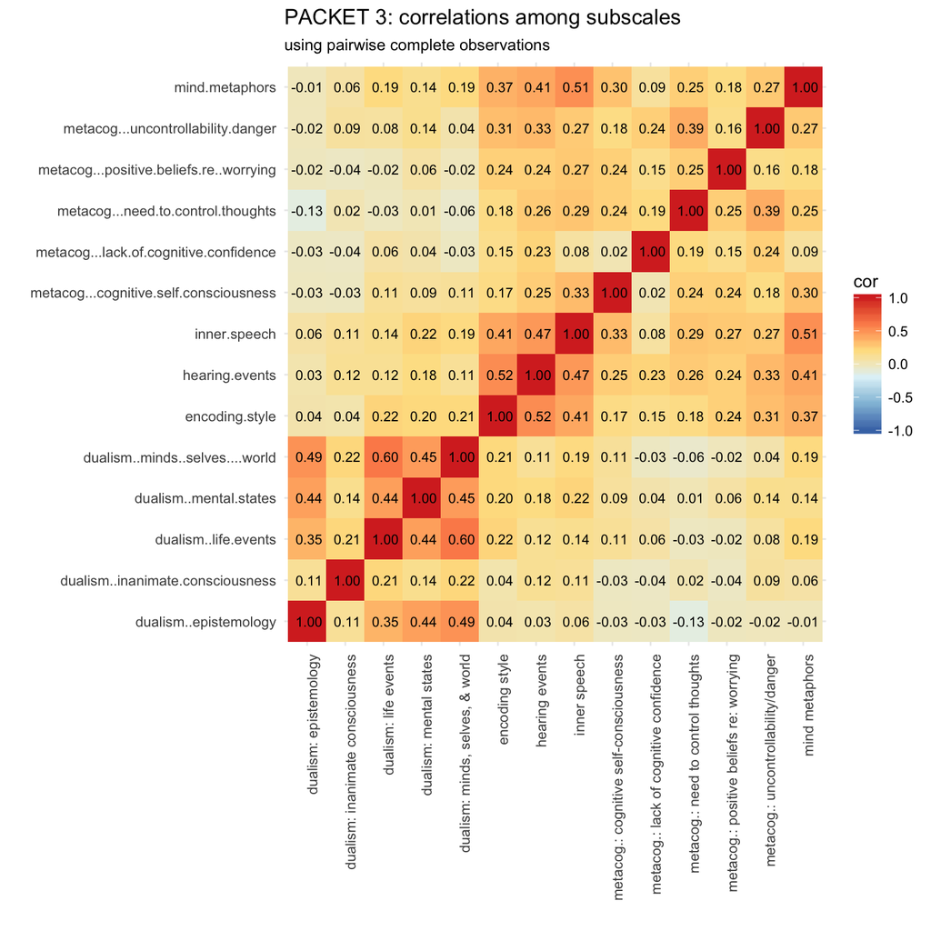

From this, we see that several of the scales included in Packet 3 were positively correlated with each other. Unsurprisingly, many of the “dualism” subscales were positively correlated. But we also see some intriguing correlations among the inner speech, hearing events, and encoding style scales - and, surprisingly, endorsement of metaphors of mind? Maybe also some correaltions with uncontrollability and need to control, as well as other metacognition subscales…? Let’s check these relationships out in more detail!

# Inner speech and hearing events

Here’s a test for the overall correlation between inner speech as measured by the Hardy/Bentall scale, and “hearing events” as measured by the Posey & Losch scale:

```
    Pearson's product-moment correlation

data:  inner speech and hearing events
t = 11.851, df = 499, p-value < 2.2e-16
alternative hypothesis: true correlation is not equal to 0
95 percent confidence interval:
 0.3973600 0.5343159
sample estimates:
      cor
0.4686493
```

Inner speech (as measured by Hardy/Bentall) was significantly positively correlated with reported hearing events ($r$ = 0.47, $p$ = <0.001), accounting for approximately 22% of the variance in reported hearing events.

Now let’s take a look at what’s going on in each site with a regression analysis:

|  | b | se | t | p |
| --- | --- | --- | --- | --- |
| baserate (overall) | 5.21 | 0.15 | 35.28 | <0.001 |
| baserate (ghana vs. overall) | -0.92 | 0.29 | -3.14 | 0.002 |
| baserate (thailand vs. overall) | 0.07 | 0.29 | 0.24 | 0.809 |
| baserate (china vs. overall) | -0.67 | 0.30 | -2.25 | 0.025 |
| baserate (vanuatu vs. overall) | 1.68 | 0.30 | 5.55 | <0.001 |
| HB inner speech (overall) | 0.24 | 0.02 | 10.82 | <0.001 |
| HB inner speech (ghana vs. overall) | 0.11 | 0.04 | 2.82 | 0.005 |
| HB inner speech (thailand vs. overall) | -0.08 | 0.04 | -1.95 | 0.052 |
| HB inner speech (china vs. overall) | 0.06 | 0.05 | 1.23 | 0.218 |
| HB inner speech (vanuatu vs. overall) | -0.06 | 0.05 | -1.36 | 0.174 |

These results indicate that there was a significant positive relationship between inner speech (as measured by Hardy/Bentall) and reported hearing events-like events, collapsing across sites ($b$ = 0.24, $p$ = <0.001). The relationship between inner voice and hearing events was somewhat stronger among participants in Ghana ($b$ = 0.11, $p$ = 0.005).

Note also that this test picked up on some differences in the baserates for reporting hearing events-like events (controlling for the relationships described above): Participants in Ghana and China seem to have reported fewer than average of these kinds of events (Ghana: $b$ = -0.92, $p$ = 0.002; China: $b$ = -0.67, $p$ = 0.025), while participants in Vanuatu seem to have reported more than average (Vanuatu: $b$ = 1.68, $p$ = <0.001).

Here’s a visualization of these relationships:

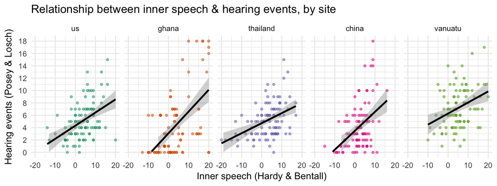

# Inner speech and encoding style

Here’s a test for the overall correlation between inner speech as measured by the Hardy/Bentall scale, and “encoding style” (which seems like a kind of hallucination-like event) as measured by the Lewicki scale:

```
    Pearson's product-moment correlation

data:  inner speech and encoding style
t = 9.8132, df = 498, p-value < 2.2e-16
alternative hypothesis: true correlation is not equal to 0
95 percent confidence interval:
 0.3263698 0.4735158
sample estimates:
      cor
0.4025399
```

Inner speech (as measured by Hardy/Bentall) was significantly positively correlated with reported encoding style ($r$ = 0.4, $p$ = <0.001), accounting for approximately 16% of the variance in reported encoding style.

Now let’s take a look at what’s going on in each site with a regression analysis:

|  | b | se | t | p |
| --- | --- | --- | --- | --- |
| baserate (overall) | 14.15 | 0.37 | 38.18 | <0.001 |
| baserate (ghana vs. overall) | 2.30 | 0.73 | 3.14 | 0.002 |
| baserate (thailand vs. overall) | -0.10 | 0.73 | -0.14 | 0.888 |
| baserate (china vs. overall) | -2.60 | 0.75 | -3.45 | <0.001 |
| baserate (vanuatu vs. overall) | -1.62 | 0.76 | -2.12 | 0.034 |
| HB inner speech (overall) | 0.53 | 0.06 | 9.41 | <0.001 |
| HB inner speech (ghana vs. overall) | 0.16 | 0.10 | 1.61 | 0.109 |
| HB inner speech (thailand vs. overall) | -0.23 | 0.10 | -2.26 | 0.024 |
| HB inner speech (china vs. overall) | -0.04 | 0.13 | -0.29 | 0.769 |
| HB inner speech (vanuatu vs. overall) | 0.00 | 0.12 | -0.01 | 0.991 |

These results indicate that there was a significant positive relationship between inner speech (as measured by Hardy/Bentall) and reported encoding style events, collapsing across sites ($b$ = 0.53, $p$ = <0.001). The relationship between inner voice and encoding style was somewhat weaker among participants in Thailand ($b$ = -0.23, $p$ = 0.024).

Note also that this test picked up on some differences in the baserates for reporting encoding style (controlling for the relationships described above): In contrast to the “hearing events” above, participants in Vanuatu seem to have reported fewer than average of these kinds of events, as did participants in China (Vanuatu: $b$ = -1.62, $p$ = 0.034; China: $b$ = -2.60, $p$ = <0.001), while participants in Ghana seem to have reported more than average (Ghana: $b$ = 2.30, $p$ = 0.002).

Here’s a visualization of these relationships:

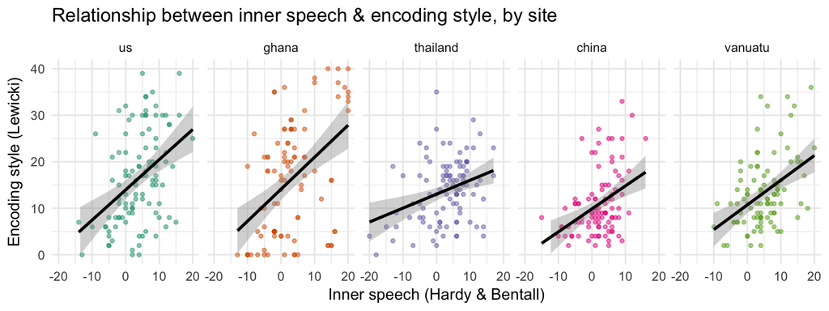

# Metacognition and inner speech

Here’s a series of tests for the overall correlations between various aspets of metacognition (as indexed by the Wells et al. subscales) and inner speech as measured by the Hardy/Bentall scale:

```
    Pearson's product-moment correlation

data:  inner speech and metacog.: lack of cognitive confidence
t = 1.8085, df = 497, p-value = 0.07113
alternative hypothesis: true correlation is not equal to 0
95 percent confidence interval:
 -0.006970079  0.167447890
sample estimates:
       cor
0.08085788


    Pearson's product-moment correlation

data:  inner speech and metacog.: positive beliefs re: worrying
t = 6.2282, df = 499, p-value = 1.003e-09
alternative hypothesis: true correlation is not equal to 0
95 percent confidence interval:
 0.1853284 0.3479867
sample estimates:
     cor
0.268571


    Pearson's product-moment correlation

data:  inner speech and metacog.: cognitive self-consciousness
t = 7.726, df = 499, p-value = 6.139e-14
alternative hypothesis: true correlation is not equal to 0
95 percent confidence interval:
 0.2463154 0.4029306
sample estimates:
      cor
0.3268653


    Pearson's product-moment correlation

data:  inner speech and metacog.: uncontrollability/danger
t = 6.0356, df = 499, p-value = 3.092e-09
alternative hypothesis: true correlation is not equal to 0
95 percent confidence interval:
 0.1772848 0.3406557
sample estimates:
      cor
0.2608368


    Pearson's product-moment correlation

data:  inner speech and metacog.: need to control thoughts
t = 6.7872, df = 499, p-value = 3.253e-11
alternative hypothesis: true correlation is not equal to 0
95 percent confidence interval:
 0.2084194 0.3689219
sample estimates:
      cor
0.2907145
```

Many aspects of metacognition were significantly positively correlated with inner speech (as measured by Hardy/Bentall) was significantly positively correlated with reported encoding style; in fact, the only one that wasn’t “significant” was the lack of cognitive confidence ($r$ = 0.08, $p$ = 0.071).

The (numerically) strongest relationship was with cognitive self-consciousness ($r$ = 0.33, $p$ = <0.001), accounting for approximately 11% of the variance in reported inner speech.

Now let’s take a closer look at this particular relationship by looking at what’s going on in each site with a regression analysis:

|  | b | se | t | p |
| --- | --- | --- | --- | --- |
| baserate (overall) | 3.83 | 0.29 | 13.3 | <0.001 |
| baserate (ghana vs. overall) | 2.40 | 0.62 | 3.9 | <0.001 |
| baserate (thailand vs. overall) | -1.13 | 0.57 | -2.0 | 0.048 |
| baserate (china vs. overall) | -1.90 | 0.56 | -3.4 | <0.001 |
| baserate (vanuatu vs. overall) | 1.12 | 0.57 | 2.0 | 0.050 |
| cog. self-consciousness (overall) | 0.51 | 0.07 | 6.9 | <0.001 |
| cog. self-consciousness (ghana vs. overall) | 0.69 | 0.13 | 5.5 | <0.001 |
| cog. self-consciousness (thailand vs. overall) | -0.34 | 0.15 | -2.2 | 0.027 |
| cog. self-consciousness (china vs. overall) | -0.22 | 0.17 | -1.3 | 0.194 |
| cog. self-consciousness (vanuatu vs. overall) | 0.03 | 0.16 | 0.2 | 0.840 |

These results indicate that there was a significant positive relationship between cognitive self-consciousness and inner speech (as measured by Hardy/Bentall), collapsing across sites ($b$ = 0.51, $p$ = <0.001). The relationship between this aspect of metacognition and inner speech was stronger among participants in Ghana ($b$ = 0.69, $p$ = <0.001), and weaker among participants in Thailand ($b$ = -0.34, $p$ = 0.027).

Note also that this test picked up on some differences in the baserates for inner speech (controlling for the relationships described above): Participants in China and (perhaps) Thailand seem to have reported fewer than average of these kinds of events (China: $b$ = -1.90, $p$ = <0.001; Thailand: $b$ = -1.13, $p$ = 0.048), while participants in Ghana and (perhaps) Vanuatu seem to have reported more than average (Ghana: $b$ = 2.40, $p$ = <0.001; Vanuatu: $b$ = 1.12, $p$ = 0.050).

Here’s a visualization of these relationships:

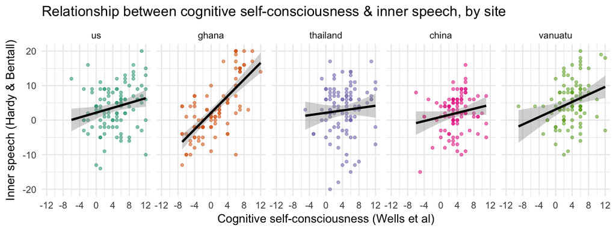

# Metacognition and hearing events

Here’s a series of tests for the overall correlations between various aspets of metacognition (as indexed by the Wells et al. subscales) and hearing events:

```
    Pearson's product-moment correlation

data:  hearing events and metacog.: lack of cognitive confidence
t = 5.2171, df = 505, p-value = 2.657e-07
alternative hypothesis: true correlation is not equal to 0
95 percent confidence interval:
 0.1418559 0.3071782
sample estimates:
      cor
0.2261449


    Pearson's product-moment correlation

data:  hearing events and metacog.: positive beliefs re: worrying
t = 5.4997, df = 507, p-value = 6.041e-08
alternative hypothesis: true correlation is not equal to 0
95 percent confidence interval:
 0.1535308 0.3176369
sample estimates:
      cor
0.2372759


    Pearson's product-moment correlation

data:  hearing events and metacog.: cognitive self-consciousness
t = 5.8735, df = 507, p-value = 7.729e-09
alternative hypothesis: true correlation is not equal to 0
95 percent confidence interval:
 0.1692052 0.3320321
sample estimates:
      cor
0.2524046


    Pearson's product-moment correlation

data:  hearing events and metacog.: uncontrollability/danger
t = 8.0028, df = 507, p-value = 8.346e-15
alternative hypothesis: true correlation is not equal to 0
95 percent confidence interval:
 0.2554159 0.4098744
sample estimates:
     cor
0.334893


    Pearson's product-moment correlation

data:  hearing events and metacog.: need to control thoughts
t = 6.1486, df = 507, p-value = 1.585e-09
alternative hypothesis: true correlation is not equal to 0
95 percent confidence interval:
 0.1806504 0.3424955
sample estimates:
      cor
0.2634257
```

The (numerically) strongest relationship was with uncontrollability/danger ($r$ = 0.33, $p$ = <0.001), accounting for approximately 11% of the variance in reported hearing events.

Now let’s take a closer look at this particular relationship by looking at what’s going on in each site with a regression analysis:

|  | b | se | t | p |
| --- | --- | --- | --- | --- |
| baserate (overall) | 5.29 | 0.15 | 34.51 | <0.001 |
| baserate (ghana vs. overall) | -0.75 | 0.30 | -2.48 | 0.013 |
| baserate (thailand vs. overall) | -0.15 | 0.30 | -0.50 | 0.619 |
| baserate (china vs. overall) | -0.64 | 0.32 | -2.04 | 0.042 |
| baserate (vanuatu vs. overall) | 1.79 | 0.31 | 5.74 | <0.001 |
| cog. uncontrol/danger (overall) | 0.26 | 0.03 | 7.37 | <0.001 |
| cog. uncontrol/danger (ghana vs. overall) | 0.42 | 0.07 | 6.33 | <0.001 |
| cog. uncontrol/danger (thailand vs. overall) | -0.17 | 0.07 | -2.53 | 0.012 |
| cog. uncontrol/danger (china vs. overall) | 0.03 | 0.08 | 0.38 | 0.705 |
| cog. uncontrol/danger (vanuatu vs. overall) | -0.13 | 0.08 | -1.74 | 0.082 |

Note also that this test picked up on some differences in the baserates for hearing events (controlling for the relationships described above): Participants in Vanuatu seem to have reported more than average of these kinds of events ($b$ = 1.79, $p$ = <0.001), while participants in Ghana seem to have reported fewer than average (Ghana: $b$ = -0.75, $p$ = 0.013).

Here’s a visualization of these relationships:

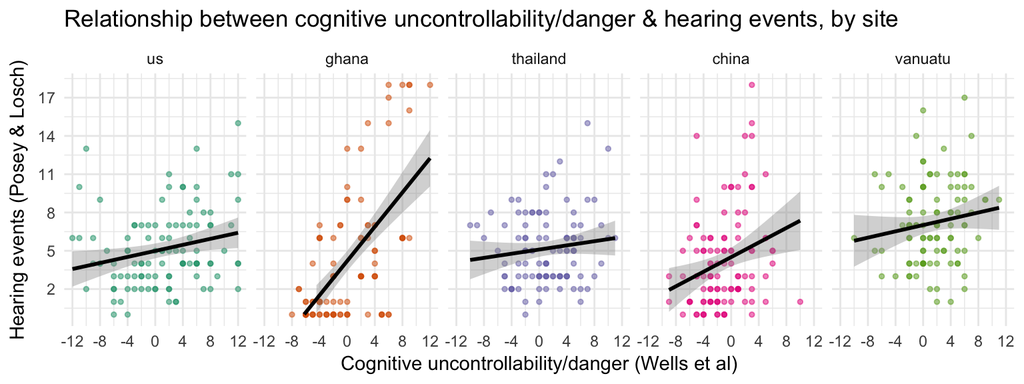